# Introduction_to_datascience

```python
import pandas as pd  # pandas
import numpy as np # numpy
import seaborn as sns # seaborn
import matplotlib.pyplot as plt
```

Unité Datascience 'Exploration et correction de données'

**Objectif**

Dans le domaine des datasciences, il est bien connu que 70 à 80% du travail réside dans l'exploration et la préparation des données, avant même ou conjointement à l'utilisation des méthodes de machine learning.

L'objectif de l'unité est d'insister sur cette partie de préparation, mais aussi de présenter quelques méthodes élémentaires de traitement. Il s'agit d'apprendre aux étudiants à lire, nettoyer, transformer un jeu de données avant de les utiliser. Les étudiants apprendront d'abord à lire des données, les caractériser et les décrire, via des statistiques descriptives et des méthodes graphiques. On leur montrera ensuite comment nettoyer, normaliser et transformer ces données, comment détecter et corriger des valeurs aberrantes, comment remplacer ou supprimer les données manquantes. On décrira ensuite comment on pourra combiner ou encoder des variables, comment extraire des informations à partir de données brutes (exemple de textes). Enfin, on décrira quelques méthodes couramment utilisées. Les cours sont largement illustrés par des TD sur machines, souvent avec des données réelles.

Compétences :

- savoir caractériser un jeu de données,
- savoir détecter et prendre en compte ou corriger des données aberrantes ou manquantes
- combiner des données élémentaires
- connaître des traitements élémentaires mais puissants d'analyse de données

# Introduction et plan

*Contenu et planning des enseignements*

0 - Présentation générale : La datascience par rapport à l'apprentissage automatique (machine learning) et à l'intelligence artificielle ? 0.5C

1 - Caractériser les données Data types, variables quantitatives, qualitatives/catégorielles Statistiques descriptives d'un jeu de données. Visualisations. Outils d'exploration des données. 2.5C + 3TP

2 - Nettoyer et transformer Conversions de types, jouer avec les dates Données manquantes. Techniques d'imputation Détection de données anormales (outliers) ; correction Normaliser et transformer les données (quand, pourquoi, comment) 3C + 4TP + 1 TD

3 - Compléter Features engineering : Combinaison de variables, regroupements, binarisation, one-hot encoding, extractions de features à partir de textes 2C + 3TP

4 - Premières applications Exemples d'application et de méthodes couramment utilisées en DS :

- plus proches voisins
- analyse en composante principale. Utilisation en réduction de dimension, regroupements
- prédiction linéaire multivariée 4C + 4TP + 1TD

5 - TP final synthétique (noté) 2TP

Cette séance :

# Table of Contents

## La datascience par rapport à l'apprentissage automatique (machine learning) et à l'intelligence artificielle ?

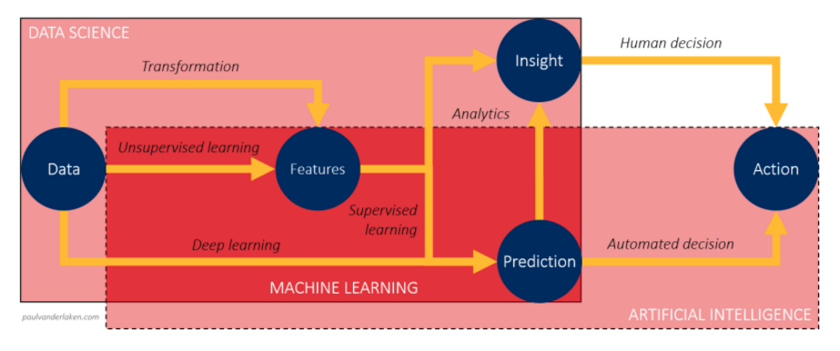

Paul van der Laken, 16 janvier 2018, “What’s the difference between data science, machine learning, and artificial intelligence?”, visualized

- Data science produces insights
- Machine learning produces predictions
- Artificial intelligence produces actions

These definitions are overly simplistic: “A fortune teller makes predictions, but we’d never say that they’re doing machine learning!”. However, I feel its a great first attempt at demystification

**Pour quoi faire ?**

- décrire des processus ou des organisations
- détecter des anomalies
- diagnostiquer les causes des événements et comportements - expliquer
- prédire
- optimiser
- recommander

"*data driven decisions*"

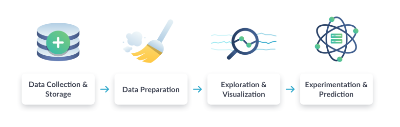

[D'après datacamp "Datascience for everyone"] Préparation et exploration se mènent csouvent conjointement.

*Où trouve-t-on des données, comment les récupérer, les lire*

- Données d'entreprise
  - web, cients, compta (flux financiers), questionnaires
- Données publiques
  - registres du commerce, insee, état
- Open data
  - API publiques twitter, wikipedia, google maps, sncf

Forme : structurées (tableaux, bases de données) ou non images, textes, paroles, géolocalisations, ...

Formats : multiples csv, xls, db, parquet, json, html, texte...

**Types de données**

- quantitatives = variables qui peuvent être mesurées numériquement
  - température,
  - nombre de connexions,
  - prix, etc
- qualitatives / catégorielles
  - groupe sanguin A, B, AB ou O.
  - la nationalité
  - le type de mot (nom, verbe, adverbe, adjectif..)
  - couleur
- ordinales = qualitatives mais avec une notion d'ordre
  - petit, moyen, grand
  - A, B, C, D, E, F (Fx)